# Aufgaben

## Aufgaben

#### Aufgabe

1. Die Varianzanalyse (ANOVA) ist ein inferenzstatistisches Verfahren des Frequentismus. Welches Skalenniveau passt zu diesem Verfahren?
   1. UV: nominal (mehrstufig), AV: metrisch
   2. UV: metrisch, AV: nominal (zweistufig)
   3. UV: nominal (mehrstufig), AV: nominal (mehrstufig)
   4. UV: metrisch, AV: nominal (zweistufig)
   5. UV: nominal (zweistufig), AV: metrisch

#### Aufgabe

2. Welches der folgenden Beispiele ist *kein* Beispiel für eine Nullhypothese?
   1. $\beta_1 <= 0$
   2. $\mu_1 = \mu_2$
   3. $\mu_1 = \mu_2 = ... = \mu_k$
   4. $\rho = 0$
   5. $\pi_1 = \pi_2$

#### Aufgabe

3. Der t-Test ist ein inferenzstatistisches Verfahren des Frequentismus. Welches Skalenniveau passt zu diesem Verfahren?
   1. UV: nominal (mehrstufig), AV: metrisch
   2. UV: metrisch, AV: nominal (zweistufig)
   3. UV: nominal (mehrstufig), AV: nominal (mehrstufig)
   4. UV: metrisch, AV: nominal (zweistufig)
   5. UV: nominal (zweistufig), AV: metrisch

#### Aufgabe

4. Für Statistiken (Stichprobe) verwendet man meist lateinische Buchstaben; für Parameter (Population) verwendet man entsprechend meist griechische Buchstaben.

   Vervollständigen Sie folgende Tabelle entsprechend!

   | Kennwert | Statistik | Parameter |
   | --- | --- | --- |
   | Mittelwert | $\bar{X}$ | NA |
   | Mittelwertsdifferenz | $\bar{X}_1-\bar{X}_2$ | NA |
   | Streuung | sd | NA |
   | Anteil | p | NA |
   | Korrelation | r | NA |
   | Regressionsgewicht | b | NA |

#### Aufgabe

5. Das Testen von Nullhypothesen wird u.a. deswegen kritisiert, weil die Nullhypothese zumeist apriori als falsch bekannt ist, weswegen es keinen Sinne mache, so die Kritiker, sie zu testen.

   Nennen Sie ein Verfahren von John Kruschke, das einen Äquivalenzbereich testet und insofern eine Alternative zum Testen von Nullhypothesen anbietet.

   Hinweise:
   - Geben Sie nur Kleinbuchstaben ein.
   - Geben Sie nur ein einziges Wort ein.

#### Aufgabe

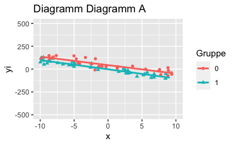

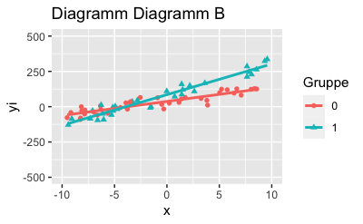

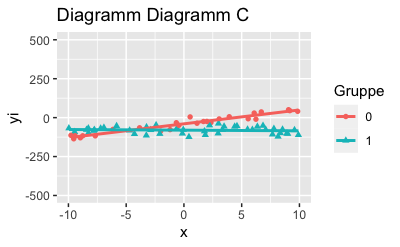

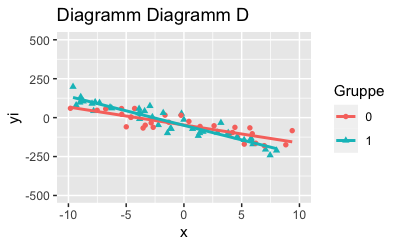

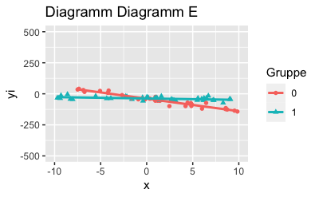

6. Wählen Sie das Diagramm, in dem *kein* Interaktionseffekt (in der Population) vorhanden ist (bzw. wählen Sie Diagramm, dass dies am ehesten darstellt).
   1. Diagramm A
   2. Diagramm B
   3. Diagramm C
   4. Diagramm D
   5. Diagramm E

#### Aufgabe

7. Ein Streudiagramm von $x$ und $y$ ergibt folgende Abbildung:

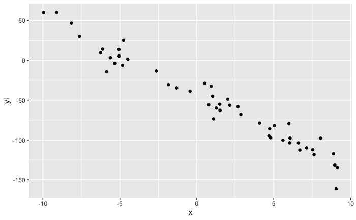

   Wählen Sie das am besten passende Modell aus der Liste aus!
   1. $y = 40 + -10 \cdot x + \epsilon$
   2. $y = -40 + -10 \cdot x + \epsilon$
   3. $y = 40 + 10 \cdot x + \epsilon$
   4. $y = -40 + 10 \cdot x + \epsilon$
   5. $y = 0 + -40 \cdot x + \epsilon$

#### Aufgabe

8. Ein Streudiagramm von $x$ und $y$ ergibt folgende Abbildung; dabei wird noch die Gruppierungsvariable $g$ (mit den Stufen `0` und `1`) berücksichtigt (vgl. Farbe und Form der Punkte). Zur besseren Orientierung ist die Regressionsgerade pro Gruppe eingezeichnet.

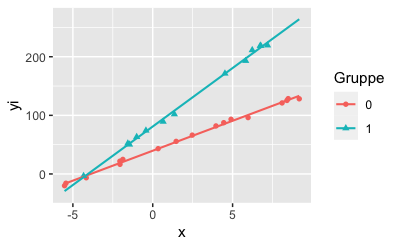

   Wählen Sie das (für die Population) am besten passende Modell aus der Liste aus!

   *Hinweis*: Ein Interaktionseffekt der Variablen $x$ und $g$ ist mit $xg$ gekennzeichnet.
   1. $y = -40 + 10\cdot x + -40 \cdot g + 0 \cdot xg + \epsilon$
   2. $y = -40 + 10\cdot x + 40 \cdot g + 0 \cdot xg + \epsilon$
   3. $y = -40 + 10\cdot x + -40 \cdot g + -10 \cdot xg + \epsilon$
   4. $y = 40 + 10\cdot x + 40 \cdot g + 10 \cdot xg + \epsilon$

#### Aufgabe

9. Gegeben sei ein Datensatz mit folgenden Prädiktoren, wobei Studierende die Beobachtungseinheit darstellen:
   - $X_1$: Geschlecht_Frau (0: nein, 1: ja)
   - $X_2$: Letzte Mathenote (z-Wert)
   - $X_3$: Alter (z-Wert)
   - $X_4$: Interaktion von $X1$ und $X2$

   Die vorherzusagende Variable ($Y$; Kriterium) ist *Gehalt nach Studienabschluss*.

   Folgende Modellparameter einer Regression (Least Squares) seien gegeben:
   - $\beta_0: 50$
   - $\beta_1: 30$
   - $\beta_2: 2$
   - $\beta_3: 1$
   - $\beta_4: 9$

   Welche der Aussagen ist korrekt?
   1. Für einen bestimmten (festen) Wert von $X_2=$ `Letzte Mathenote (z-Wert)` und $X_3=$ `Alter (z-Wert)` gilt, dass das Gehalt im Mittel höher ist bei $X_1=1$ im Vergleich zu $X_1=0$, laut dem Modell.
   2. Für einen bestimmten (festen) Wert von $X_2$= `Letzte Mathenote (z-Wert)` und $X_3$= `Alter (z-Wert)` gilt, dass das Gehalt im Mittel höher ist bei $X_1=0$ im Vergleich zu $X_1=1$, laut dem Modell.
   3. Der mittlere Gehaltsunterschied $Y$ zweier Personen $a$ und $b$, wobei bei Person $a$ gilt $X_1=0$ und bei Person $b$ gilt $X_1=1$, beträgt stets $50$, laut dem Modell.
   4. Der mittlere Gehaltsunterschied $Y$ zweier Personen $a$ und $b$, wobei bei Person $a$ gilt $X_1=0$ und bei Person $b$ gilt $X_1=1$, kann *nicht* ohne weitere Angaben auf eine Zahl fixiert werden, laut dem Modell.
   5. Der mittlere Gehaltsunterschied von Menschen ist eine Wirkung von genau drei Ursachen: `Geschlecht_Frau (0: nein, 1: ja)`, `Letzte Mathenote (z-Wert)`, `Alter (z-Wert)`, laut dem Modell.

#### Aufgabe

10. Welches Ergebnis hat der R-Befehl `posterior_interval()` (R-Paket `rstanarm`)?

    Wählen Sie die (am besten) passende Antwort aus.

    Hinweis:
    - Soweit nicht anders benannt, ist immer die Voreinstellung der betreffenden Funktion gemeint.
    1. Er liefert einen Vorhersagewert aus der Posteriori-Verteilung.
    2. Er liefert ein Vorhersageintervall aus der Posteriori-Verteilung.
    3. Er liefert ein 90%-Vorhersageintervall aus der Posteriori-Verteilung.
    4. Er liefert ein 95%-Vorhersageintervall aus der Posteriori-Verteilung.
    5. Er liefert ein HDI-Vorhersageinterval aus der Posteriori-Verteilung.

#### Aufgabe

11. Betrachten Sie folgende Ausgabe eines Bayesmodell, das mit `rstanarm` “gefittet” wurde:

    ```
    ## stan_glm
    ##  family:       gaussian [identity]
    ##  formula:      price ~ cut
    ##  observations: 1000
    ##  predictors:   5
    ## ------
    ##              Median  MAD_SD
    ## (Intercept)   4571.7   675.1
    ## cutGood       -570.2   777.2
    ## cutIdeal     -1288.3   688.1
    ## cutPremium     362.5   709.8
    ## cutVery Good  -807.4   706.3
    ##
    ## Auxiliary parameter(s):
    ##       Median MAD_SD
    ## sigma 3795.0   82.4
    ```

    Welche Aussage passt (am besten)?

    Hinweise:
    - Mit “Nullhypothese” ist im Folgenden dieser Ausdruck gemeint: $\mu_1 = \mu_2 = \ldots = \mu_k$.
    - Gehen Sie davon aus, dass die Posteriori-Verteilungen der Regressionskoeffizienten normalverteilt sind.
    - Beziehen Sie sich bei den Antworten auf die oben dargestellten Daten.
    1. Die Nullhypothese ist falsch und muss daher verworfen werden.
    2. Die Nullhypothese ist wahr und muss daher beibehalten werden.
    3. Man kann schließen, dass bei allen Gruppenmittelwerte der Wert Null außerhalb des 95%-PI der Posteriori-Verteilung liegt.
    4. Man kann *nicht* schließen, dass bei allen Gruppenmittelwerte der Wert Null außerhalb des 95%-PI der Posteriori-Verteilung liegt.
    5. Man kann schließen, dass bei keinem der Gruppenmittelwerte der Wert Null außerhalb des 95%-PI der Posteriori-Verteilung liegt.

#### Aufgabe

12. Berechnet man eine Posteriori-Verteilung mit `stan_glm()`, so kann man entweder die schwach informativen Prioriwerte der Standardeinstellung verwenden, oder selber Prioriwerte definieren.

    Betrachten Sie dazu dieses Modell:

    ```
    stan_glm(price ~ cut, data = diamonds,
                       prior = normal(location = c(100, 100, 100, 100),
                                      scale = c(100, 100, 100, 100)),
                       prior_intercept = normal(3000, 500))
    ```

    Welche Aussage dazu passt (am besten)?
    1. Es wird für (genau) einen Parameter eine Priori-Verteilung definiert.
    2. Für keinen Parameter liegt apriori die Wahrscheinlichkeit für einen negativen Wert bei mehr als 5%.
    3. Mit `prior = normal()` werden Gruppenmittelwerte definiert.
    4. Alle Parameter des Modells sind normalverteilt.
    5. mit `prior_intercept = normal(3000, 500)` wird praktisch eine Gleichverteilung definiert (da die Streuung sehr hoch ist).

#### Aufgabe

13. Berechnet man eine Posteriori-Verteilung mit `stan_glm()`, so kann man entweder die schwach informativen Prioriwerte der Standardeinstellung verwenden, oder selber Prioriwerte definieren.

    Betrachten Sie dazu dieses Modell:

    ```
    stan_glm(price ~ cut, data = diamonds,
                       prior = normal(location = c(100, 100, 100, 100),
                                      scale = c(100, 100, 100, 100)),
                       prior_intercept = normal(3000, 500))
    ```

    Wie viele Parameter gibt es in diesem Modell?

    Hinweise:
    - Geben Sie nur eine (ganze) Zahl ein.

#### Aufgabe

14. Sei $X \sim \mathcal{N}(42, 7)$ und $x_1 = 28$.

    Berechnen Sie den z-Wert für $x_1$!

    Hinweis:
    - Runden Sie ggf. auf die nächste ganze Zahl.

#### Aufgabe

15. John Kruschke hat einen (Absolut-)Wert vorschlagen, als Grenze für Regressionskoeffizienten “vernachlässigbarer” Größe.

    Nennen Sie diesen Wert!

    Hinweise:
    - Geben Sie nur Zahlen ein (und ggf. Dezimaltrennzeichen).
    - Führende Nullen dürfen auch bei Zahlen kleiner als 1 nicht weggelassen werden.

#### Aufgabe

16. Im Datensatz `mtcars`: Ist der (mittlere) Unterschied im Spritverbrauch zwischen den beiden Gruppen *Automatik* vs. *Schaltgetriebe* vernachlässigbar?

    Definieren Sie selber, was “vernachlässigbar klein” bedeutet. Oder greifen Sie auf die Definition “höchstens eine Meile” zurück.

    Prüfen Sie rechnerisch, anhand des angegebenen Datensatzes, folgende Behauptung:

    *Behauptung: “Der Unterschied ist vernachlässigbar klein!”*

    Wählen Sie die Antwortoption, die am besten zu der obigen Behauptung passt!

    Hinweise:
    - Sie benötigen einen Computer, um diese Aufgabe zu lösen.
    - Verwenden Sie die statistischen Methoden, die im Unterricht behandelt wurden.
    - Verwenden Sie Ansätze aus der Bayes-Statistik zur Lösung dieser Aufgabe.

    *Antwortoptionen*:
    1. Ja, die Behauptung ist korrekt.
    2. Nein, die Behauptung ist falsch.
    3. Die Daten sind bzw. das Modell nicht konkludent; es ist keine Entscheidung über die Behauptung möglich.
    4. Auf Basis der bereitgestellten Informationen ist keine Entscheidung möglich über die Behauptung.

#### Aufgabe

17. Einer der (bisher) größten Studien der Untersuchung psychologischer Konsequenzen (oder Korrelate) der Covid-Zeit ist die Studie [COVIDiStress](https://www.nature.com/articles/s41597-020-00784-9).

    Im Folgenden sollen Sie folgende Forschungsfrage untersuchen:

    *Ist der Zusammenhang von Stress (`PSS10_avg`, AV) und Neurotizismus (`neu`, UV) vernachlässigbar klein?*

    Den Datensatz können Sie so herunterladen (Achtung, groß):

    ```
    osf_d_path <- "https://osf.io/cjxua/?action=download"

    d <- read_csv(osf_d_path)
    ```

    Hinweise:
    - Sie benötigen einen Computer, um diese Aufgabe zu lösen.
    - Verwenden Sie die statistischen Methoden, die im Unterricht behandelt wurden.
    - Verwenden Sie Ansätze aus der Bayes-Statistik zur Lösung dieser Aufgabe.
    - Bei der Variable für Geschlecht können Sie sich auf Fälle begrenzen, die Männer und Frauen umfassen.
    - Wandeln Sie die die Variable für Geschlecht in eine binäre Variable - also Werte mit 0 und 1 - um.
    - Alle Daten (und weitere Informationen) zum Projekt sind [hier](https://osf.io/z39us/) abgelegt.
    - Eine Beschreibung der Variablen der Studie finden Sie [hier](https://moodle.hs-ansbach.de/mod/url/view.php?id=79230).

    *Antwortoptionen*
    1. Ja
    2. Nein
    3. Die Daten sind nicht konkludent; es ist keine Entscheidung möglich.
    4. Auf Basis der bereitgestellten Informationen ist keine Entscheidung möglich.

#### Aufgabe

18. Einer der (bisher) größten Studien der Untersuchung psychologischer Konsequenzen (oder Korrelate) der Covid-Zeit ist die Studie [COVIDiStress](https://www.nature.com/articles/s41597-020-00784-9).

    Im Folgenden sollen Sie folgende Forschungsfrage untersuchen:

    *Forschungsfrage*:

    Ist der Unterschied zwischen Männern und Frauen (`Dem_gender`) im Hinblick zum Zusammenhang von Stress (`PSS10_avg`, AV) und Neurotizismus (`neu`, UV) vernachlässigbar klein?

    Den Datensatz können Sie so herunterladen (Achtung, groß):

    ```
    osf_d_path <- "https://osf.io/cjxua/?action=download"

    d <- read_csv(osf_d_path)
    ```

    Hinweise:
    - Sie benötigen einen Computer, um diese Aufgabe zu lösen.
    - Verwenden Sie die statistischen Methoden, die im Unterricht behandelt wurden.
    - Verwenden Sie Ansätze aus der Bayes-Statistik zur Lösung dieser Aufgabe.
    - Bei der Variable für Geschlecht können Sie sich auf Fälle begrenzen, die Männer und Frauen umfassen.
    - Wandeln Sie die die Variable für Geschlecht in eine binäre Variable - also Werte mit 0 und 1 - um.
    - Alle Daten (und weitere Informationen) zum Projekt sind [hier](https://osf.io/z39us/) abgelegt.
    - Eine Beschreibung der Variablen der Studie finden Sie [hier](https://moodle.hs-ansbach.de/mod/url/view.php?id=79230).

    *Antwortoptionen:*
    1. Ja
    2. Nein
    3. Die Daten sind nicht konkludent; es ist keine Entscheidung möglich.
    4. Auf Basis der bereitgestellten Informationen ist keine Entscheidung möglich.